# Replication_Peijin_pl724

Peijin Li

2022/5/3

Replication: Do Women Give Up Competing More Easily? Evidence from the Lab and the Dutch Math Olympiad

Author of the paper: Thomas Buser & Huaiping Yuan

Journal and link: American Economic Journal: Applied Economics 2019, 11(3): 225–252 https://doi.org/10.1257/app.20170160

```r
rm(list=ls())
```

```r
## set path
setwd("C:/Users/little page/Desktop/rep_stats")
getwd()

## get libraries
library(fBasics)
library(ggplot2)
library(grid)
library(gridExtra)
library(datasets)
library(haven)
library(xtable)
library(knitr)
library(car)
library(ggplot2)
library(ivreg)
library(statar)
library(broom)
library(data.table) ## For some minor data wrangling
library(fixest)     ## NB: Requires version >=0.9.0
library(tidyverse)
library(plm)
library(miceadds)
library(lmtest)
library(multiwayvcov)
library(stargazer)
```

This paper mainly answers the question: *Do women give up competing more easily?* The authors use lab experiments and field data from the Dutch Math Olympiad to conduct this research. My replication focuses on the field study part. **In this part, the authors use the field data from the Dutch Math Olympiad to determine whether the gender difference in the reaction to losing carries over to the field**.

1 Background

The goal of the Dutch Mathematical Olympiad is to select a national team to represent the Netherlands in the International Mathematical Olympiad. The first round of the competition consists of a two-hour test. Only the pre-determined best performers from the first round will advance to the second round. The threshold scores for advancement were determined flexibly to select approximately N top performers. Participants in the fourth year of secondary school or lower, regardless of their scores, are free to participate in the latter year. **This paper takes the binary decision of whether to compete again one year later as the outcome measure**.

This study uses anonymized data for all participants in the 2010–2014 Olympiads, including their score, gender, and whether they participated again the year after. The data present a **sharp regression discontinuity design** because winning and losing depends on a strict cutoff (the threshold score). **Comparing the subsequent participation choices of individuals just below and just above the cutoff makes it possible to estimate the causal effect of losing versus winning on the likelihood of participating again one year later**. In particular, this paper is interested in the gender difference in this effect.

The authors employ two commonly used approaches to estimating the regression discontinuity design: linear and quadratic polynomial. In the linear regressions, they restrict the sample to observations close to the cutoff and control linearly for the forcing variable (first-round score). The polynomial approach consists of using a higher bandwidth. This is because the data is very discrete (only whole points can be scored). Using a second-order polynomial means estimating three parameters on either side of the cutoff on a small number of data points. To avoid overfitting, the linear approach is therefore preferable for small bandwidths.

2 Replication and Results

2.1 Regression results

In this thesis, I replicated the results of Figure 2,3,4 of the paper. Firstly, I conducted a set of estimates. I made subsets of boys and girls separately and estimate the following equation and present regression discontinuity results separately for each gender:

$$Y_i = \alpha + \beta_1T_i + \beta_2NetScore_i + \beta_3 NetScore_i \cdot T_i + \epsilon_i(1),$$

where Y is a binary indicator for participating again a year later, T is a binary indicator for scoring above the cutoff (that is, making the second round).

$$Y_i = \alpha + \beta_1T_i + \beta_2 F_i + \beta_3NetScore_i + \beta_4 NetScore_i \cdot T_i + \beta_5 F_i \cdot T_i + \beta_6 F_i \cdot NetScore_i + \epsilon_i(2),$$
to learn the gender difference, I added F as a binary indicator for being female and an interaction variable of F and T, which estimates the gender difference in the reaction to loss. I also interacted the NetScore with the cutoff indicator T to allow for different slopes left and right of the cutoff. And the interaction of NetScore and T with F to allow for different slopes for each gender.

**To remove unobserved heterogeneity between students from different schools, I introduced school fixed effects, and I also clustered the standard errors at the score level to account for situations where observations within each score group are not independently and identically distributed**. In practice, I estimated the following equation:

$$Y_i = \alpha + \beta_1T_i + \beta_2NetScore_i + \beta_3 NetScore_i \cdot T_i + \gamma_s + \epsilon_i(3),$$

$$Y_i = \alpha + \beta_1T_i + \beta_2 F_i + \beta_3NetScore_i + \beta_4 NetScore_i \cdot T_i + \beta_5 F_i \cdot T_i + \beta_6 F_i \cdot NetScore_i + \gamma_s + \epsilon_i(4).$$

```r
## get data
matholympiad=read_dta("matholympiad.dta")
dim(matholympiad)
```

```
## [1] 11591    13
```

```r
head(matholympiad)
```

| Leerlingnummer | t | School | NetScore | Score | R2NetScore | R2Score | y | gender | x0 | T | rank | genderrank |
| --- | --- | --- | --- | --- | --- | --- | --- | --- | --- | --- | --- | --- |
| 4154 | 10 | 100 | -4 | 8 | NA | NA | 0 | 0 | -4 | 0 | 0.5763856 | 0.5540839 |
| 389 | 10 | 187 | -6 | 6 | NA | NA | 1 | 0 | -6 | 0 | 0.3893976 | 0.3704930 |
| 4134 | 10 | 24 | -8 | 4 | NA | NA | 0 | 0 | -8 | 0 | 0.2098795 | 0.1986755 |
| 3407 | 10 | 27 | 1 | 13 | 5 | 23 | 0 | 0 | 1 | 1 | 0.8568675 | 0.8370125 |
| 2382 | 10 | 108 | -4 | 8 | NA | NA | 0 | 0 | -4 | 0 | 0.5763856 | 0.5540839 |
| 2461 | 10 | 89 | -4 | 8 | NA | NA | 1 | 0 | -4 | 0 | 0.5763856 | 0.5540839 |

[output not shown]

```r
##subset girls data(gender==1)
girls_data = subset(matholympiad, gender== 1)
##subset boys data(gender==0)
boys_data = subset(matholympiad, gender== 0)

#use a bandwidth of +/- 5 around the score for the analysis.
girls_data_five = girls_data[abs(girls_data$NetScore) < 6,]
boys_data_five = boys_data[abs(boys_data$NetScore) < 6,]
#use a bandwidth of +/- 5 around the score for the analysis.
girls_data_ten = girls_data[abs(girls_data$NetScore) < 11,]
boys_data_ten = boys_data[abs(boys_data$NetScore) < 11,]
```

```r
##regression on both gender
girls_reg = lm(y ~ NetScore + T + I(NetScore * T),data = girls_data_five)
#summary(girls_reg)
boys_reg = lm(y ~ NetScore + T + I(NetScore * T),data = boys_data_five)
#summary(boys_reg)
stargazer(girls_reg,boys_reg, type="text", title = "Linear Regression")
```

```
##
## Linear Regression
## =====================================================================
##                                    Dependent variable:
##                     -------------------------------------------------
##                                             y
##                               (1)                      (2)
## ---------------------------------------------------------------------
## NetScore                     0.019*                  0.033***
##                             (0.011)                  (0.008)
##
## T                           0.143**                   -0.019
##                             (0.062)                  (0.042)
##
## I(NetScore * T)              -0.017                   -0.011
##                             (0.022)                  (0.015)
##
## Constant                    0.531***                 0.628***
##                             (0.041)                  (0.029)
##
## ---------------------------------------------------------------------
## Observations                 1,252                    2,379
## R2                           0.034                    0.022
## Adjusted R2                  0.032                    0.021
## Residual Std. Error    0.492 (df = 1248)        0.491 (df = 2375)
## F Statistic         14.800*** (df = 3; 1248) 18.055*** (df = 3; 2375)
## =====================================================================
## Note:                                     *p<0.1; **p<0.05; ***p<0.01
```

```r
##regression on gender difference:The parameter of I(T * gender) is our interest.
gd_reg= lm(y ~ T + gender + I(T * gender) + NetScore + I(T * NetScore) + I(gender * NetScore) + I(T * NetScore *gender), data = matholympiad)
summary(gd_reg)
```

```
##
## Call:
## lm(formula = y ~ T + gender + I(T * gender) + NetScore + I(T *
##     NetScore) + I(gender * NetScore) + I(T * NetScore * gender),
##     data = matholympiad)
##
## Residuals:
##     Min      1Q  Median      3Q     Max
## -0.9474 -0.4202 -0.3185  0.5362  0.7782
##
## Coefficients:
##                            Estimate Std. Error t value Pr(>|t|)
## (Intercept)               0.5509783  0.0136894  40.248  < 2e-16 ***
## T                         0.0778070  0.0253293   3.072  0.00213 **
## gender                   -0.0419039  0.0225587  -1.858  0.06326 .
## I(T * gender)             0.0853844  0.0466614   1.830  0.06729 .
## NetScore                  0.0145305  0.0014514  10.011  < 2e-16 ***
## I(T * NetScore)           0.0014023  0.0037169   0.377  0.70597
## I(gender * NetScore)     -0.0008527  0.0023430  -0.364  0.71590
## I(T * NetScore * gender) -0.0017138  0.0079447  -0.216  0.82922
## ---
## Signif. codes:  0 '***' 0.001 '**' 0.01 '*' 0.05 '.' 0.1 ' ' 1
##
## Residual standard error: 0.4841 on 11583 degrees of freedom
## Multiple R-squared:  0.05365,    Adjusted R-squared:  0.05308
## F-statistic: 93.81 on 7 and 11583 DF,  p-value: < 2.2e-16
```

```r
##knitr: output hook with an output.lines= option
library(knitr)
hook_output <- knit_hooks$get("output")
knit_hooks$set(output = function(x, options) {
   lines <- options$output.lines
   if (is.null(lines)) {
     return(hook_output(x, options))  # pass to default hook
   }
   x <- unlist(strsplit(x, "\n"))
   more <- "..."
   if (length(lines)==1) {        # first n lines
     if (length(x) > lines) {
       # truncate the output, but add ....
       x <- c(head(x, lines), more)
     }
   } else {
     x <- c(if (abs(lines[1])>1) more else NULL,
            x[lines],
            if (length(x)>lines[abs(length(lines))]) more else NULL
           )
   }
   # paste these lines together
   x <- paste(c(x, ""), collapse = "\n")
   hook_output(x, options)
 })
```

```r
#{r, output.lines=8}

##regression on both gender with school fixed effects and cluster the standard errors at the score level.(Girls)
girls_reg_fixed = feols(y ~ NetScore + T + I(NetScore * T) + factor(School), vcov = ~Score,data = girls_data_five)
summary(girls_reg_fixed)
```

```
## OLS estimation, Dep. Var.: y
## Observations: 1,252
## Standard-errors: Clustered (Score)
##                    Estimate Std. Error   t value Pr(>|t|)
## (Intercept)        0.423541   0.363184  1.166188 0.257969
## NetScore           0.018041   0.011090  1.626813 0.120248
## T                  0.125958   0.078277  1.609124 0.124079
## I(NetScore * T)   -0.022311   0.020588 -1.083681 0.292067
...
```

```r
##{r, output.lines=8}

##regression on both gender with school fixed effects and cluster the standard errors at the score level.(Boys)
boys_reg_fixed = feols(y ~ NetScore + T + I(NetScore * T)+ factor(School), vcov = ~Score,data = boys_data_five)
summary(boys_reg_fixed)
```

```
## OLS estimation, Dep. Var.: y
## Observations: 2,379
## Standard-errors: Clustered (Score)
##                    Estimate Std. Error   t value  Pr(>|t|)
## (Intercept)        0.561182   0.180348  3.111659 0.0057438 **
## NetScore           0.034534   0.009818  3.517411 0.0023025 **
## T                 -0.039231   0.053165 -0.737907 0.4695874
## I(NetScore * T)   -0.009874   0.014528 -0.679642 0.5049281
...
```

```r
##{r, output.lines=12}

##regression on gender difference with school fixed effects and cluster the standard errors at the score level.
gd_reg_fixed = feols(y ~ T + gender + I(T * gender) + NetScore + I(T * NetScore) + I(gender * NetScore) + I(T * NetScore *gender) + factor(School), vcov = ~Score, data = matholympiad)
summary(gd_reg_fixed)
```

```
## OLS estimation, Dep. Var.: y
## Observations: 11,591
## Standard-errors: Clustered (Score)
##                           Estimate Std. Error    t value   Pr(>|t|)
## (Intercept)               0.632302   0.050485  12.524529 7.0426e-14 ***
## T                         0.067011   0.037700   1.777477 8.4996e-02 .
## gender                   -0.048130   0.013265  -3.628248 9.8253e-04 ***
## I(T * gender)             0.088275   0.054091   1.631969 1.1249e-01
## NetScore                  0.016234   0.001814   8.949214 3.1873e-10 ***
## I(T * NetScore)           0.001965   0.003707   0.530210 5.9963e-01
## I(gender * NetScore)     -0.001019   0.001436  -0.710201 4.8272e-01
## I(T * NetScore * gender) -0.001104   0.007393  -0.149287 8.8226e-01
...
```

According to the results, we could see that in the non-clustered regression, the coefficient of our interest T is 0.143, which means that those girls who get a score higher than the threshold, have a 14.3% higher possibility of participating in the competition in the following year. This difference between girls is statistically significant under the confidence level of 95%. In other words, **according to girls who score within 5 points of the cutoff, the effect of losing roughly translates to a 14.3 percent reduction in the likelihood of participating again**.

For boys, the influence of their score results on the following year’s participation is not significant. In regression (2), we could see that the gender difference in the reaction to losing is significant, with a confidence level of 90%. However, these differences are not significant with school fixed effects and standard errors clustered at the score level.

2.2 Regression discontinuity graphs

In Figure 2, **I presented regression discontinuity graphs using both the linear and polynomial approaches**. Panel A shows the data close to the cutoff (plus-minus 5 points) and linear regression lines. Following the paper, the first-round scores are normalized such that a score of zero or above means passing the threshold. Panel B shows a wider bandwidth (plus-minus 10 points) and quadratic approximations. **In both cases, it is evident that there is a sizable drop at the cutoff in the likelihood of participating again for girls but not for boys**. I yielded the same result as the paper in the part.

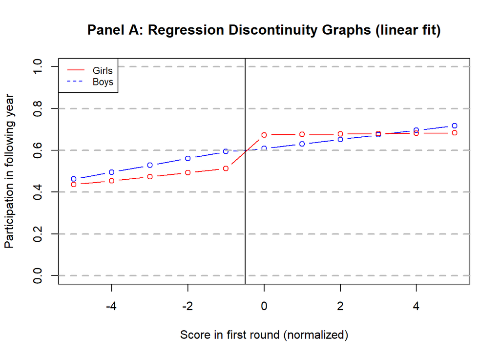

```r
#Figure 2. Regression Discontinuity Graphs
#Panel A: Regression Discontinuity Graphs (linear fit) shows the data close to the cutoff (plus-minus 5 points) and linear regression lines.

#boys_reg = lm(y ~ NetScore + T + I(NetScore * T),data = boys_data)
boys_data_five$pred_poly1 = predict(boys_reg, newdata = boys_data_five)
#girls_reg = lm(y ~ NetScore + T + I(NetScore * T),data = girls_data)
girls_data_five$pred_poly1 = predict(girls_reg, newdata = girls_data_five)

#prepare the dataset for plot
plotdata1=aggregate(girls_data_five$pred_poly1, list(girls_data_five$NetScore), FUN=mean)
plotdata2=aggregate(boys_data_five$pred_poly1, list(boys_data_five$NetScore), FUN=mean)

plot(plotdata2$Group.1,plotdata2$x,type="b",col="blue",xlab="Score in first round (normalized)",ylab="Participation in following year",main="Panel A: Regression Discontinuity Graphs (linear fit)", ylim = c(0, 1))
points(plotdata1$Group.1,plotdata1$x,type="b",col="red")
abline(v=-0.5, col="black")
grid(nx = NA,ny = NULL,lty = 2, col = "gray", lwd = 2)

legend("topleft",c("Girls", "Boys"),col=c("red", "blue"), lty=1:2, cex=0.8)
```

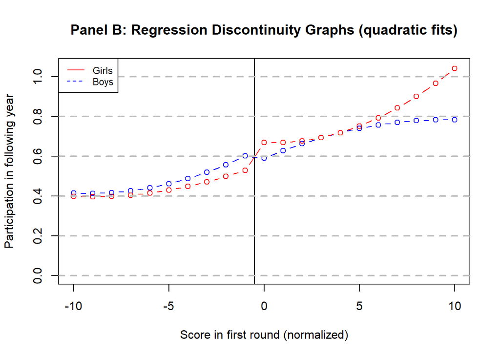

```r
###Figure 2. Regression Discontinuity Graphs
#Panel B: Regression Discontinuity Graphs (quadratic fits) shows a wider bandwidth(plus-minus 10 points) and quadratic approximations.

##create quadratic polynomial of the forcing variable
boys_data_ten$NetScore_2 = boys_data_ten$NetScore^2
girls_data_ten$NetScore_2 = girls_data_ten$NetScore^2

##quadratic polynomial regression
boys_reg2 = lm(y ~  T + NetScore + NetScore_2 + I(NetScore * T) + I(NetScore_2 * T), data = boys_data_ten)
boys_data_ten$pred_poly2 = predict(boys_reg2, newdata = boys_data_ten)
girls_reg2 = lm(y ~  T + NetScore + NetScore_2 + I(NetScore * T) + I(NetScore_2 * T), data = girls_data_ten)
girls_data_ten$pred_poly2 = predict(girls_reg2, newdata = girls_data_ten)

#prepare the dataset for plot
plotdata3=aggregate(girls_data_ten$pred_poly2, list(girls_data_ten$NetScore), FUN=mean)
plotdata4=aggregate(boys_data_ten$pred_poly2, list(boys_data_ten$NetScore), FUN=mean)

plot(plotdata4$Group.1,plotdata4$x,type="b",col="blue",xlab="Score in first round (normalized)",ylab="Participation in following year",main="Panel B: Regression Discontinuity Graphs (quadratic fits)", ylim = c(0, 1.05))
points(plotdata3$Group.1,plotdata3$x,type="b",col="red")
abline(v=-0.5, col="black")
grid(nx = NA,ny = NULL,lty = 2, col = "gray", lwd = 2)

legend("topleft",c("Girls", "Boys"),col=c("red", "blue"), lty=1:2, cex=0.8)
```

2.3 Discontinuity estimates for varying bandwidths

Figures 3 and 4 show OLS estimates of the discontinuity for a range of score bandwidths around the cutoff using the linear and quadratic approaches. **In all regressions, I clustered the standard errors at the score level**. And **error bars represent 90 percent confidence intervals**. For the linear approach, I started with a bandwidth of 4 and for the quadratic approach, I started with a bandwidth of 7.

```r
##Figure 3. Discontinuity Estimates for Varying Bandwidths (Linear)
##Panel A: Boys

##loop through the bwidths
CoefMatrix_li_boys  = matrix(NA, 7, 5)# Matrix to store our results
bwidths = seq(from=4, to=10, by=1)
for(ii in 1:length(bwidths)) {
  bw_reg = lm.cluster(y ~ NetScore + T + I(T * NetScore) , cluster='Score', data = boys_data[abs(boys_data$NetScore) < bwidths[ii],])
  CoefMatrix_li_boys[ii,1]= bwidths[ii]
  CoefMatrix_li_boys[ii,2]= coefficients(bw_reg)[3]
  CoefMatrix_li_boys[ii,3]= summary(bw_reg)[ , "Std. Error"][3]
  CoefMatrix_li_boys[ii,4]= coefficients(bw_reg)[3] - 1.64*CoefMatrix_li_boys[ii,3]##: Error bars represent 90 percent confidence intervals.
  CoefMatrix_li_boys[ii,5]= coefficients(bw_reg)[3] + 1.64*CoefMatrix_li_boys[ii,3]##: Error bars represent 90 percent confidence intervals.
}

##put the result into a df
d_li_boys <- data.frame(bwidths = CoefMatrix_li_boys[,1], point.estimate = CoefMatrix_li_boys[,2], ci.upper = CoefMatrix_li_boys[,4], ci.lower = CoefMatrix_li_boys[,5])
```

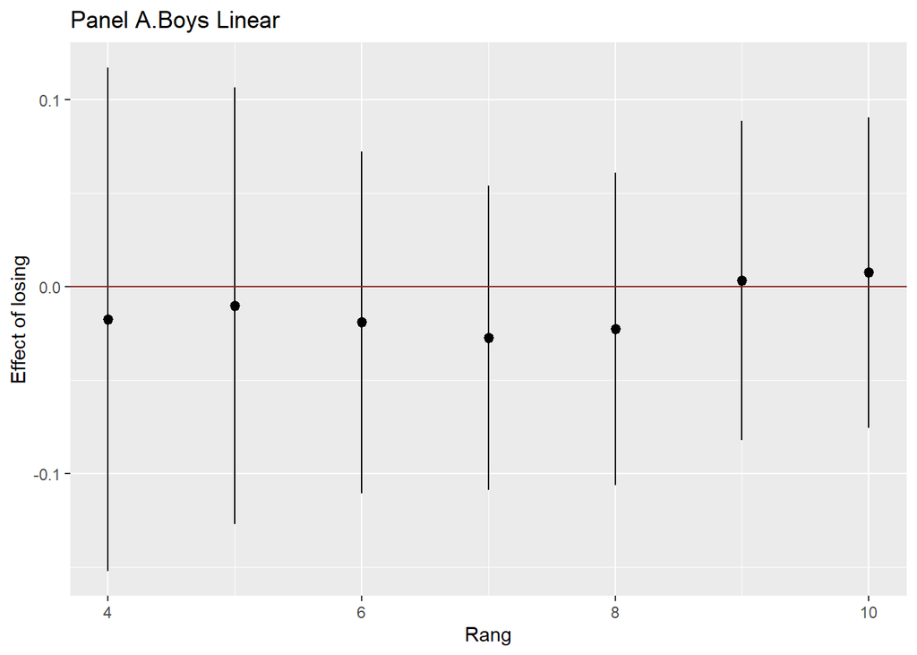

```r
#plot
ggplot(data=d_li_boys, mapping = aes(x = bwidths, y = point.estimate, ymin = ci.lower, ymax = ci.upper)) +
    geom_pointrange(size = 0.4) +
    geom_hline(yintercept = 0, colour="brown4") +
    ggtitle("Panel A.Boys Linear") +
    xlab("Rang") +
    ylab("Effect of losing")
```

```r
##Figure 3. Discontinuity Estimates for Varying Bandwidths (Linear)
##Panel B: Girls

##loop through the bwidths
CoefMatrix_li_girls = matrix(NA, 7, 5)# Matrix to store our results
bwidths = seq(from=4, to=10, by=1)
for(ii in 1:length(bwidths)) {
  bw_reg = lm.cluster(y ~ NetScore + T + I(T * NetScore) , cluster='Score', data = girls_data[abs(girls_data$NetScore) < bwidths[ii],])##cluster the standard errors at the score level
  CoefMatrix_li_girls[ii,1]= bwidths[ii]
  CoefMatrix_li_girls[ii,2]= coefficients(bw_reg)[3]
  CoefMatrix_li_girls[ii,3]= summary(bw_reg)[ , "Std. Error"][3]
  CoefMatrix_li_girls[ii,4]= coefficients(bw_reg)[3] - 1.64*CoefMatrix_li_girls[ii,3]##: Error bars represent 90 percent confidence intervals.
  CoefMatrix_li_girls[ii,5]= coefficients(bw_reg)[3] + 1.64*CoefMatrix_li_girls[ii,3]##: Error bars represent 90 percent confidence intervals.
}

##put the result into a df
d_li_girls <- data.frame(bwidths = CoefMatrix_li_girls[,1], point.estimate = CoefMatrix_li_girls[,2], ci.upper = CoefMatrix_li_girls[,4], ci.lower = CoefMatrix_li_girls[,5])
```

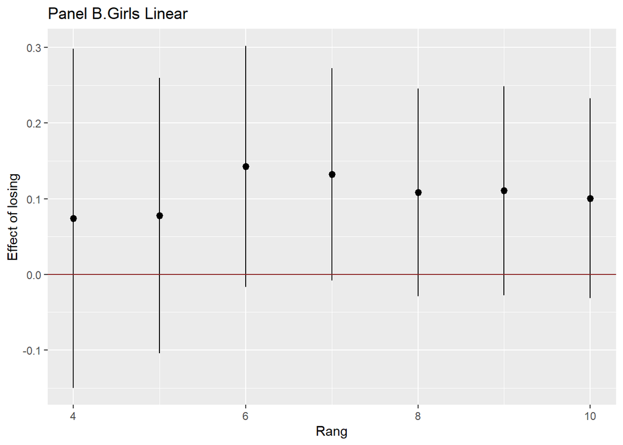

```r
#plot
ggplot(data=d_li_girls, mapping = aes(x = bwidths, y = point.estimate, ymin = ci.lower, ymax = ci.upper)) +
    geom_pointrange(size = 0.4) +
    geom_hline(yintercept = 0, colour="brown4") +
    ggtitle("Panel B.Girls Linear") +
    xlab("Rang") +
    ylab("Effect of losing")
```

```r
##Figure 3. Discontinuity Estimates for Varying Bandwidths (Linear)
##Panel C: Gender difference

##loop through the bwidths
CoefMatrix_li_gd    = matrix(NA, 7, 5)# Matrix to store our results
bwidths = seq(from=4, to=10, by=1)
for(ii in 1:length(bwidths)) {
  bw_reg = lm.cluster(y ~ T + gender + I(T * gender) + NetScore + I(T * NetScore) + I(gender * NetScore) + I(T * NetScore *gender), cluster='Score', data = matholympiad[abs(matholympiad$NetScore) < bwidths[ii],])##cluster the standard errors at the score level
  CoefMatrix_li_gd[ii,1]= bwidths[ii]
  CoefMatrix_li_gd[ii,2]= coefficients(bw_reg)[4]
  CoefMatrix_li_gd[ii,3]= summary(bw_reg)[ , "Std. Error"][4]
  CoefMatrix_li_gd[ii,4]= coefficients(bw_reg)[4] - 1.64*CoefMatrix_li_gd[ii,3]##: Error bars represent 90 percent confidence intervals.
  CoefMatrix_li_gd[ii,5]= coefficients(bw_reg)[4] + 1.64*CoefMatrix_li_gd[ii,3]##: Error bars represent 90 percent confidence intervals.
}

##put the result into a df
d_li_gd <- data.frame(bwidths = CoefMatrix_li_gd[,1], point.estimate = CoefMatrix_li_gd[,2], ci.upper = CoefMatrix_li_gd[,4], ci.lower = CoefMatrix_li_gd[,5])
```

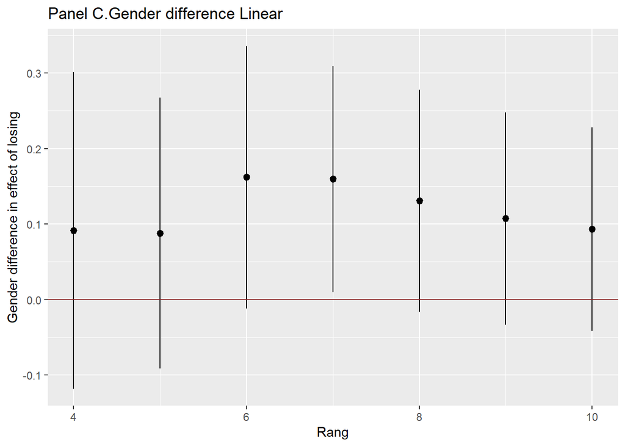

```r
#plot
ggplot(data=d_li_gd, mapping = aes(x = bwidths, y = point.estimate, ymin = ci.lower, ymax = ci.upper)) +
    geom_pointrange(size = 0.4) +
    geom_hline(yintercept = 0, colour="brown4") +
    ggtitle("Panel C.Gender difference Linear") +
    xlab("Rang") +
    ylab("Gender difference in effect of losing")
```

```r
##Figure 4. Discontinuity Estimates for Varying Bandwidths (Quadratic)
##Panel A: Boys

##create quadratic polynomial of the forcing variable
boys_data$NetScore_2 = boys_data$NetScore^2
girls_data$NetScore_2 = girls_data$NetScore^2
matholympiad$NetScore_2 = matholympiad$NetScore^2

##loop through the bwidths
CoefMatrix_qu_boys  = matrix(NA, 14, 5)# Matrix to store our results
bwidths = seq(from=7, to=20, by=1)
for(ii in 1:length(bwidths)) {
  bw_reg = lm.cluster(y ~ T + NetScore + NetScore_2 + I(NetScore * T) + I(NetScore_2 * T), cluster='Score', data = boys_data[abs(boys_data$NetScore) < bwidths[ii],])##cluster the standard errors at the score level
  CoefMatrix_qu_boys[ii,1]= bwidths[ii]
  CoefMatrix_qu_boys[ii,2]= coefficients(bw_reg)[2]
  CoefMatrix_qu_boys[ii,3]= summary(bw_reg)[ , "Std. Error"][2]
  CoefMatrix_qu_boys[ii,4]= coefficients(bw_reg)[2] - 1.64*CoefMatrix_qu_boys[ii,3]##: Error bars represent 90 percent confidence intervals.
  CoefMatrix_qu_boys[ii,5]= coefficients(bw_reg)[2] + 1.64*CoefMatrix_qu_boys[ii,3]##: Error bars represent 90 percent confidence intervals.
}

##put the result into a df
d_qu_boys <- data.frame(bwidths = CoefMatrix_qu_boys[,1], point.estimate = CoefMatrix_qu_boys[,2], ci.upper = CoefMatrix_qu_boys[,4], ci.lower = CoefMatrix_qu_boys[,5])
```

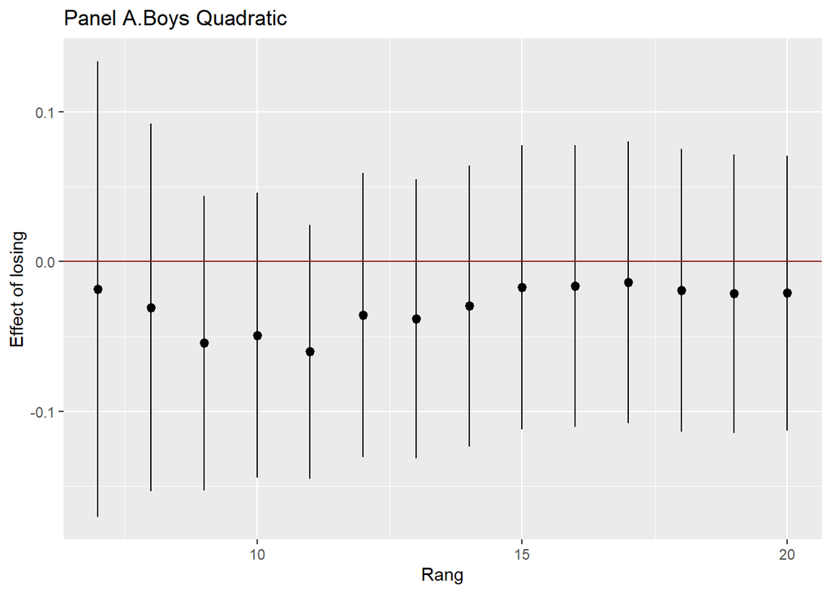

```r
#plot
ggplot(data=d_qu_boys, mapping = aes(x = bwidths, y = point.estimate, ymin = ci.lower, ymax = ci.upper)) +
    geom_pointrange(size = 0.4) +
    geom_hline(yintercept = 0, colour="brown4") +
    ggtitle("Panel A.Boys Quadratic") +
    xlab("Rang") +
    ylab("Effect of losing")
```

```r
##Figure 4. Discontinuity Estimates for Varying Bandwidths (Quadratic)
#Panel B: Girls

##loop through the bwidths
CoefMatrix_qu_girls = matrix(NA, 14, 5)# Matrix to store our results
bwidths = seq(from=7, to=20, by=1)
for(ii in 1:length(bwidths)) {
  bw_reg = lm.cluster(y ~ T + NetScore + NetScore_2 + I(NetScore * T) + I(NetScore_2 * T), cluster='Score', data = girls_data[abs(girls_data$NetScore) < bwidths[ii],])##cluster the standard errors at the score level
  CoefMatrix_qu_girls[ii,1]= bwidths[ii]
  CoefMatrix_qu_girls[ii,2]= coefficients(bw_reg)[2]
  CoefMatrix_qu_girls[ii,3]= summary(bw_reg)[ , "Std. Error"][2]
  CoefMatrix_qu_girls[ii,4]= coefficients(bw_reg)[2] - 1.64*CoefMatrix_qu_girls[ii,3]##: Error bars represent 90 percent confidence intervals.
  CoefMatrix_qu_girls[ii,5]= coefficients(bw_reg)[2] + 1.64*CoefMatrix_qu_girls[ii,3]##: Error bars represent 90 percent confidence intervals.
}

##put the result into a df
d_qu_girls <- data.frame(bwidths = CoefMatrix_qu_girls[,1], point.estimate = CoefMatrix_qu_girls[,2], ci.upper = CoefMatrix_qu_girls[,4], ci.lower = CoefMatrix_qu_girls[,5])
```

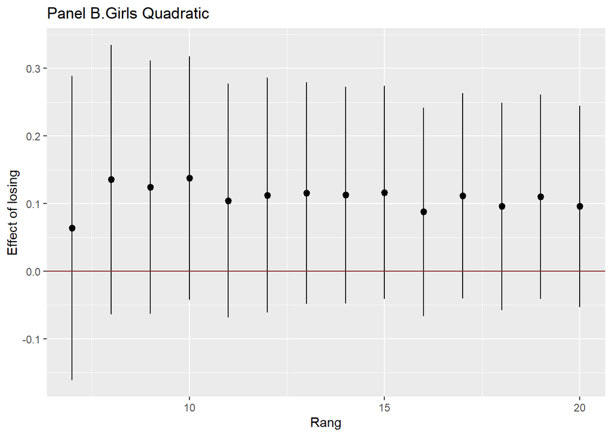

```r
#plot
ggplot(data=d_qu_girls, mapping = aes(x = bwidths, y = point.estimate, ymin = ci.lower, ymax = ci.upper)) +
    geom_pointrange(size = 0.4) +
    geom_hline(yintercept = 0, colour="brown4") +
    ggtitle("Panel B.Girls Quadratic") +
    xlab("Rang") +
    ylab("Effect of losing")
```

```r
##Figure 4. Discontinuity Estimates for Varying Bandwidths (Quadratic)
##Panel C: Gender difference

##loop through the bwidths
CoefMatrix_qu_gd    = matrix(NA, 14, 5)# Matrix to store our results
bwidths = seq(from=7, to=20, by=1)
for(ii in 1:length(bwidths)) {
  bw_reg = lm.cluster(y ~ T + gender + I(T * gender) + NetScore + I(T * NetScore) + I(gender * NetScore) + I(T * NetScore *gender) + NetScore_2 + I(NetScore_2 * T)+I(gender * NetScore_2) + I(T * NetScore_2 *gender), cluster='Score', data = matholympiad[abs(matholympiad$NetScore) < bwidths[ii],])##cluster the standard errors at the score level
  CoefMatrix_qu_gd[ii,1]= bwidths[ii]
  CoefMatrix_qu_gd[ii,2]= coefficients(bw_reg)[4]
  CoefMatrix_qu_gd[ii,3]= summary(bw_reg)[ , "Std. Error"][4]
  CoefMatrix_qu_gd[ii,4]= coefficients(bw_reg)[4] - 1.64*CoefMatrix_qu_gd[ii,3]##: Error bars represent 90 percent confidence intervals.
  CoefMatrix_qu_gd[ii,5]= coefficients(bw_reg)[4] + 1.64*CoefMatrix_qu_gd[ii,3]##: Error bars represent 90 percent confidence intervals.
}

##put the result into a df
d_qu_gd <- data.frame(bwidths = CoefMatrix_qu_gd[,1], point.estimate = CoefMatrix_qu_gd[,2], ci.upper = CoefMatrix_qu_gd[,4], ci.lower = CoefMatrix_qu_gd[,5])
```

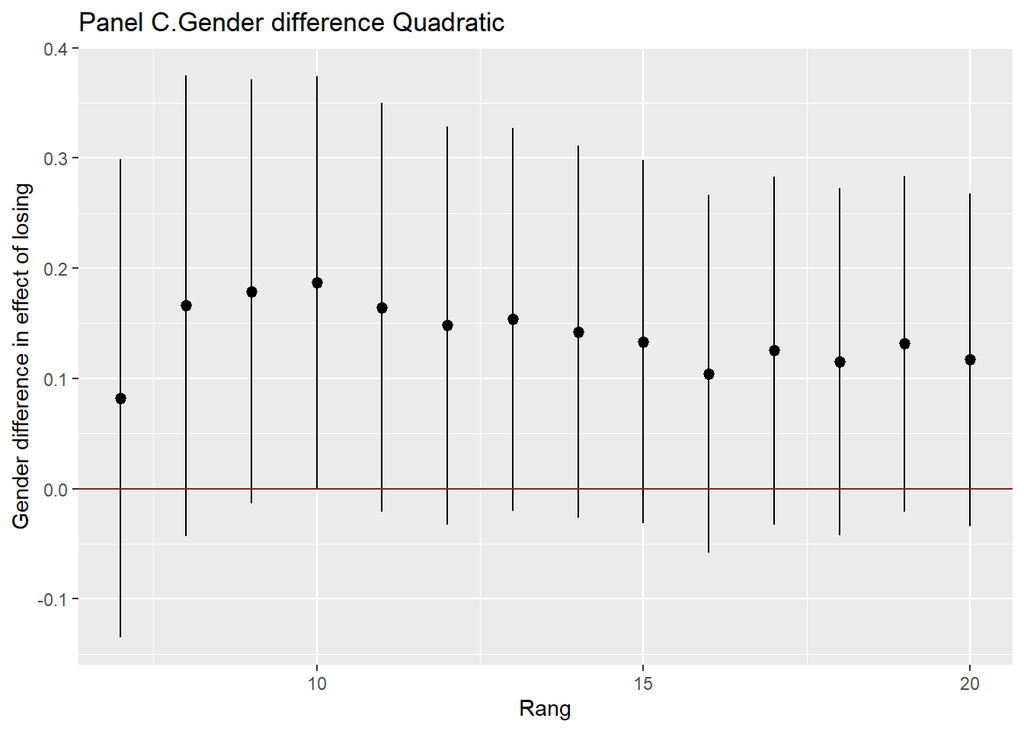

```r
#plot
ggplot(data=d_qu_gd, mapping = aes(x = bwidths, y = point.estimate, ymin = ci.lower, ymax = ci.upper)) +
    geom_pointrange(size = 0.4) +
    geom_hline(yintercept = 0, colour="brown4") +
    ggtitle("Panel C.Gender difference Quadratic") +
    xlab("Rang") +
    ylab("Gender difference in effect of losing")
```

3 Robustness Test

```r
##Test on all bandwidths(Linear):

##loop through the bwidths
CoefMatrix_li_gd    = matrix(NA, 20, 5)# Matrix to store our results
bwidths = seq(from=1, to=20, by=1)
for(ii in 1:length(bwidths)) {
  bw_reg = lm.cluster(y ~ T + gender + I(T * gender) + NetScore + I(T * NetScore) + I(gender * NetScore) + I(T * NetScore *gender), cluster='Score', data = matholympiad[abs(matholympiad$NetScore) < bwidths[ii],])##cluster the standard errors at the score level
  CoefMatrix_li_gd[ii,1]= bwidths[ii]
  CoefMatrix_li_gd[ii,2]= coefficients(bw_reg)[4]
  CoefMatrix_li_gd[ii,3]= summary(bw_reg)[ , "Std. Error"][4]
  CoefMatrix_li_gd[ii,4]= coefficients(bw_reg)[4] - 1.64*CoefMatrix_li_gd[ii,3]##: Error bars represent 90 percent confidence intervals.
  CoefMatrix_li_gd[ii,5]= coefficients(bw_reg)[4] + 1.64*CoefMatrix_li_gd[ii,3]##: Error bars represent 90 percent confidence intervals.
}
```

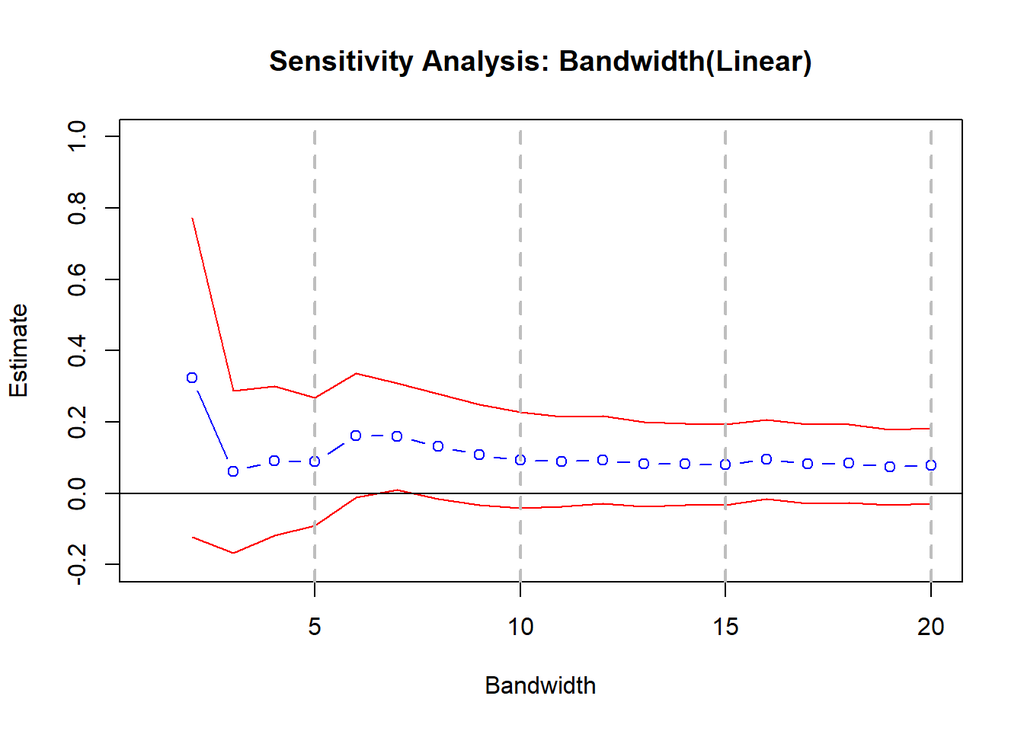

```r
#plot
plot(CoefMatrix_li_gd[,1],CoefMatrix_li_gd[,2],type="b",col="blue",xlab="Bandwidth",ylab="Estimate",main="Sensitivity Analysis: Bandwidth(Linear)",ylim=c(-0.2,1))
lines(CoefMatrix_li_gd[,1],CoefMatrix_li_gd[,4],type="l",col="red")
lines(CoefMatrix_li_gd[,1],CoefMatrix_li_gd[,5],type="l",col="red")
abline(h=0, col="black")
grid(nx = NULL, ny = NA, lty = 2, col = "gray", lwd = 2)
```

```r
#Test on all bandwidths(Quadratic):

##loop through the bwidths
CoefMatrix_qu_gd    = matrix(NA, 20, 5)# Matrix to store our results
bwidths = seq(from=1, to=20, by=1)
for(ii in 1:length(bwidths)) {
  bw_reg = lm.cluster(y ~ T + gender + I(T * gender) + NetScore + I(T * NetScore) + I(gender * NetScore) + I(T * NetScore *gender) + NetScore_2 + I(NetScore_2 * T)+I(gender * NetScore_2) + I(T * NetScore_2 *gender), cluster='Score', data = matholympiad[abs(matholympiad$NetScore) < bwidths[ii],])##cluster the standard errors at the score level
  CoefMatrix_qu_gd[ii,1]= bwidths[ii]
  CoefMatrix_qu_gd[ii,2]= coefficients(bw_reg)[4]
  CoefMatrix_qu_gd[ii,3]= summary(bw_reg)[ , "Std. Error"][4]
  CoefMatrix_qu_gd[ii,4]= coefficients(bw_reg)[4] - 1.64*CoefMatrix_qu_gd[ii,3]##: Error bars represent 90 percent confidence intervals.
  CoefMatrix_qu_gd[ii,5]= coefficients(bw_reg)[4] + 1.64*CoefMatrix_qu_gd[ii,3]##: Error bars represent 90 percent confidence intervals.
}
```

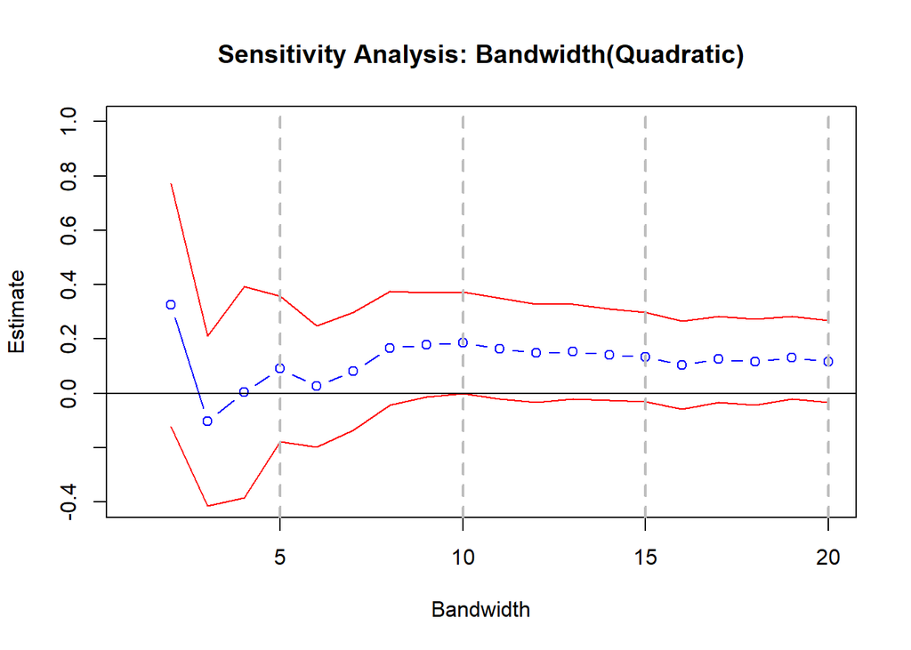

```r
#plot
plot(CoefMatrix_qu_gd[,1],CoefMatrix_qu_gd[,2],type="b",col="blue",xlab="Bandwidth",ylab="Estimate",main="Sensitivity Analysis: Bandwidth(Quadratic)",ylim=c(-0.4,1))
lines(CoefMatrix_qu_gd[,1],CoefMatrix_qu_gd[,4],type="l",col="red")
lines(CoefMatrix_qu_gd[,1],CoefMatrix_qu_gd[,5],type="l",col="red")
abline(h=0, col="black")
grid(nx = NULL, ny = NA, lty = 2, col = "gray", lwd = 2)
```

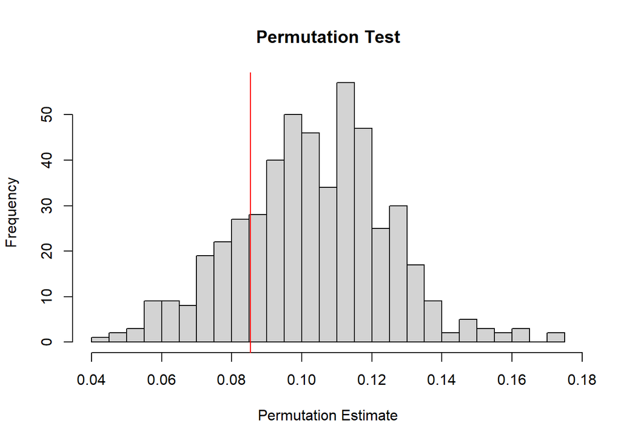

```r
#Implement a permutation test to assess the credibility of the gender difference:

reps = 500
CoefMatrix  = matrix(NA, reps, 1)   # Matrix to store our results.
for(ii in 1:reps) {matholympiad$p_gender = sample(0:1, dim(matholympiad)[1], replace = TRUE)
  ##Generate random gender data
  p_gd_reg = lm(y ~ T + p_gender + I(T * p_gender) + NetScore + I(T * NetScore) + I(p_gender * NetScore) + I(T * NetScore *p_gender), data = matholympiad)
  CoefMatrix[ii,1]=coefficients(p_gd_reg)[2]
}

##draw the graph
hist(CoefMatrix[,1],breaks=20,main="Permutation Test",xlab="Permutation Estimate")
abline(v=0.0853844, col="red")##mark the original coefficient
```

4 Parting Thoughts

References

- Abadie, Alberto, et al. When Should You Adjust Standard Errors for Clustering? Oct. 2017.
- Buser, Thomas, et al. “Do Women Give Up Competing More Easily? Evidence from the Lab and the Dutch Math Olympiad.” American Economic Journal: Applied Economics, 2019, pp. 225–52.